# Place à la pratique ! Premiers pas sur R

Anaïs Vignoles

2025-09-17

## 1- Introduction

Dans cette introduction, nous allons découvrir les bases du langage de programmation R.

Tout d’abord, tout le texte précédé par un **#** est ce qu’on appelle un **commentaire**.

```r
# commentaire
```

Ce sont des lignes qui ne seront pas exécutées par le code et qui nous permettront de décrire les étapes du script. Bien commenter son code est très important car cela nous permet de le comprendre facilement même après des mois et des années sans y avoir travaillé (en théorie !). Cela nous permet aussi de le partager avec d’autres personnes, pour qu’elles comprennent tout de suite notre démarche.

Nous allons travailler ici avec un jeu de données fictif appelé **“data_exemple_ext”**. Il s’agit d’un tableau décrivant plusieurs données qualitatives, quantitatives et spatiales de l’industrie lithique d’une collection.

Pour faciliter notre travail, on va créer un **projet R**. Cela va nous permettre :

1. de rassembler tous les éléments liés à notre séance au sein d’un même dossier.
2. de simplifier notre code, car nos commandes “path” seront toujours précédées par le path du projet
3. de partager plus facilement notre travail (toutes les données nécessaires au fonctionnement du script seront partagées avec lui) ou de le transférer à un autre ordinateur (puisque le path sera automatiquement modifié !).

Pour créer un projet, nous pouvons cliquer sur le bouton en haut à droite de RStudio.

> New project…

Puis sélectionnez ou créez le dossier dans lequel vous allez mettre votre script et vos données.

Remarquez bien que dans l’onglet “Files” dans le panneau en bas à droite, nous sommes directement dans le dossier du projet !

**NB:** Personnellement, j’organise tous mes projets de la même façon : trois sous-dossiers :

> **“data”** qui contiendra toutes les données brutes utilisées dans ce projet

> **“script”** qui contiendra tous les scripts utilisés

> **“output”** dans lequel on sauvegardera les résultats de nos codes (tableaux, figures etc).

En consultant l’onglet “Files” du panneau en bas à droite, on voit que nos dossiers ont bien été créés !

## 2- Ouvrir un jeu de données

Nous allons commencer par ouvrir le jeu de données “data_exemple_ext” en utilisant le bouton **“Import dataset”** dans l’onglet “Environnement” en haut à droite. Ce bouton permet d’écrire automatiquement le code pour importer un tableau csv.

Vous pouvez également utiliser une ligne de code toute simple pour importer votre jeu de données (plus reproductible et très pratique lorsque l’on utilise les projets R !)

```r
jdd <- read.csv("data_exemple_ext.csv", sep = ",", header = T)
```

Vous venez d’ouvrir le tableau dans R ! Il a été stocké dans un objet que l’on a appelé “jdd”. Si vous l’appelez dans la console, il s’affichera, vous permettant de l’explorer.

```r
jdd
```

```
##    numero            type x_cm y_cm z_cm couche longueur_cm largeur_cm  silex
## 1      18            lame   80  100  102   US 1         7.4        1.9 type A
## 2      24           eclat  210  340  109   US 1         9.5        7.1 type A
## 3      13            lame   20   50  117   US 1         9.2        3.1 type A
## 4      30           eclat  280  370  121   US 1         1.9        1.2 type A
## 5      11            lame   80   90  124   US 1        10.0        2.8 type A
## 6       9  chute de burin  230  280  130   US 1         2.0        0.5 type A
## 7      23           eclat  260  390  135   US 1         4.5        3.6 type A
## 8      10 nucleus a lames  180  290  137   US 1        10.2        6.9 type A
## 9      25           eclat  230  370  137   US 1         5.8        4.2 type A
## 10     31           eclat  260  300  137   US 1         4.6        2.8 type A
## 11     16            lame   40   50  138   US 1         9.8        3.1 type A
## 12     33           eclat  200  280  141   US 1         2.3        2.2 type A
## 13     21           eclat  280  350  144   US 1         8.4        5.9 type A
## 14     12            lame   50   70  146   US 1         8.5        2.7 type A
```

[output cut: 53 more lines]

Il est également possible, dans l’onglet “Environment” en haut à droite, d’ouvrir le jeu de données en cliquant sur le petit tableau situé sur la ligne “jdd”.

Afin de ne pas encombrer la console, il est aussi possible de n’afficher que les 6 premières lignes du tableau avec `head()`.

```r
head(jdd)
```

```
##   numero           type x_cm y_cm z_cm couche longueur_cm largeur_cm  silex
## 1     18           lame   80  100  102   US 1         7.4        1.9 type A
## 2     24          eclat  210  340  109   US 1         9.5        7.1 type A
## 3     13           lame   20   50  117   US 1         9.2        3.1 type A
## 4     30          eclat  280  370  121   US 1         1.9        1.2 type A
## 5     11           lame   80   90  124   US 1        10.0        2.8 type A
## 6      9 chute de burin  230  280  130   US 1         2.0        0.5 type A
##   raccord année
## 1      NA  2021
## 2      NA  2021
## 3      NA  2021
## 4      NA  2021
## 5      NA  2021
## 6       2  2021
```

## 3- Explorer un jeu de données

On peut vérifier la classe d’objet de jdd par la commande suivante :

```r
class(jdd)
```

```
## [1] "data.frame"
```

Un data frame est un type d’objet R correspondant à un tableau. Il existe plusieurs classes que nous découvrirons au fur et à mesure.

`class()` est ce qu’on appelle une fonction. C’est une opération qui sera appliquée à un objet. La fonction class() permet d’afficher la classe de l’objet auquel on applique cette fonction. Lorsque l’on ne comprends pas l’objectif d’une fonction ou que l’on a oublié, on peut demander de l’aide par la fonction `help()` ou plus simplement `?`.

```r
?class

help(class) # notez que ces deux commandes ont le même résultat.
```

A présent je souhaite obtenir des informations statistiques générales sur les différentes dimensions du tableau. On utilise la fonction `summary()`.

```r
summary(jdd)
```

```
##      numero       type                x_cm            y_cm
##  Min.   : 1   Length:33          Min.   : 10.0   Min.   : 50.0
##  1st Qu.: 9   Class :character   1st Qu.: 50.0   1st Qu.: 90.0
##  Median :17   Mode  :character   Median :210.0   Median :280.0
##  Mean   :17                      Mean   :174.8   Mean   :217.6
##  3rd Qu.:25                      3rd Qu.:260.0   3rd Qu.:340.0
##  Max.   :33                      Max.   :290.0   Max.   :390.0
##
##       z_cm          couche           longueur_cm     largeur_cm
##  Min.   :102.0   Length:33          Min.   : 1.4   Min.   :0.500
##  1st Qu.:137.0   Class :character   1st Qu.: 4.5   1st Qu.:1.900
##  Median :158.0   Mode  :character   Median : 5.9   Median :2.800
##  Mean   :163.2                      Mean   : 5.8   Mean   :2.976
##  3rd Qu.:197.0                      3rd Qu.: 7.4   3rd Qu.:3.700
##  Max.   :215.0                      Max.   :10.2   Max.   :7.100
##
##     silex              raccord         année
##  Length:33          Min.   :1.00   Min.   :2021
##  Class :character   1st Qu.:1.25   1st Qu.:2021
##  Mode  :character   Median :2.00   Median :2022
##                     Mean   :2.00   Mean   :2022
##                     3rd Qu.:2.75   3rd Qu.:2023
##                     Max.   :3.00   Max.   :2023
##                     NA's   :27
```

On obtient des informations telles que le min/max/moyenne etc de chaque variable numérique.

On peut aussi afficher certaines informations sur les dimensions du tableau, comme le nombre de colonnes, de lignes.

```r
nrow(jdd) # nb de lignes
```

```
## [1] 33
```

```r
ncol(jdd) # nb de colonnes
```

```
## [1] 11
```

Pour vérifier le type de variable dans un tableau (ce sera important car certaines fonctions nécessitent un type de variable particulier), on peut appliquer la fonction `class()` sur chaque variable séparément par l’opérateur `$`.

```r
class(jdd$type)
```

```
## [1] "character"
```

```r
class(jdd$longueur_cm)
```

```
## [1] "numeric"
```

La variable “longueur” est de classe *numérique* tandis que la variable “type” est de classe *character*. Or, pour traiter des variables catégorielles avec R il vaut mieux utiliser le format *factor*. Nous allons donc convertir la variable “type” en factor avec la fonction `factor()` :

```r
jdd$type <- factor(jdd$type) # cette commande signifie au pied de la lettre : dans la colonne "type" du data frame "jdd", je mets la colonne "type" du data frame "jdd" convertie en facteur
```

On vérifie que le code a bien fonctionné avec `class()`.

```r
class(jdd$type)
```

```
## [1] "factor"
```

**NB:** généralement quand on modifie les données primaires, il vaut toujours mieux créer une nouvelle colonne afin de garder une trace des données brutes. On aurait pu faire quelque chose comme cela :

```r
jdd$type_fac <- as.factor(jdd$type)

class(jdd$type_fac) # même résultat !
```

```
## [1] "factor"
```

Nous pouvons à présent vérifier les différentes valeurs que peut prendre une variable catégorielle, par la fonction `levels()`.

```r
levels(jdd$type)
```

```
##  [1] "burin"           "burin diedre"    "burin du Raysse" "chute de burin"
##  [5] "eclat"           "gravette"        "lame"            "nucleus a lames"
##  [9] "percoir"         "picardie"
```

Ces quelques fonctions sont utiles pour explorer les données et se rendre compte d’erreurs à un stade préliminaire.

## 4- Créer un graphique simple

### A- Premiers pas

A présent, essayons de visualiser un graphique de la longueur vs la largeur des pièces. Dans R base, on utilise la fonction `plot()`.

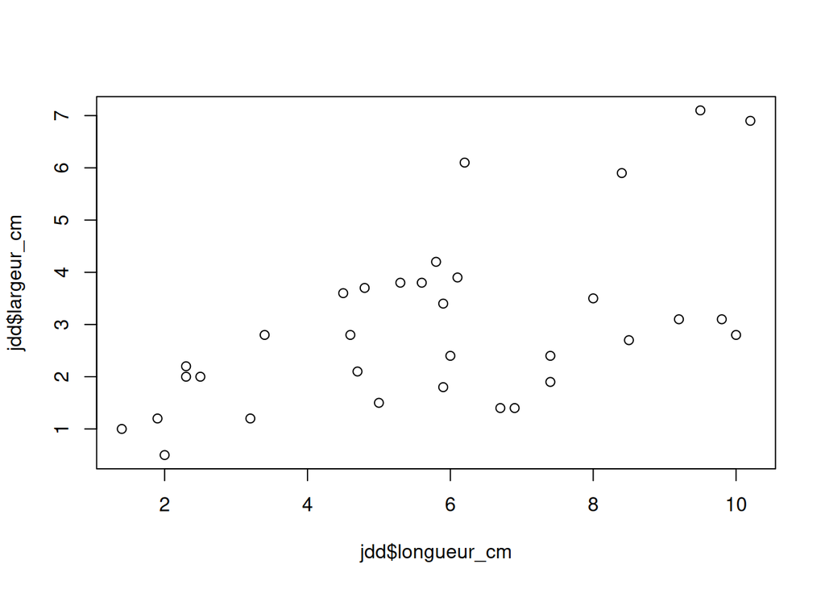

```r
plot(x = jdd$longueur_cm, y = jdd$largeur_cm)
```

Ici, à l’intérieur de la fonction, on a précisé quels arguments étaient concernés. Un **argument** est un objet que l’on passera à la fonction pour qu’elle s’éxécute. Les fonctions comme `class()`, `levels()` n’ont qu’un argument, c’est pourquoi nous n’avons pas eu besoin de le préciser. De façon générale, les arguments sont rentrés dans l’ordre chronologique dans lequel ils sont programmés dans la fonction. Voyons voir cela de plus près.

```r
?plot
```

Dans la fiche d’aide, nous pouvons voir que cette fonction nécessite deux arguments au minimum : **x** (l’abcisse) et **y** (l’ordonnée). Il est possible de préciser ou non dans le code quels objets vont dans quels arguments, mais ce n’est pas nécessaire. Ainsi, la commande suivante aura le même résultat que précédemment.

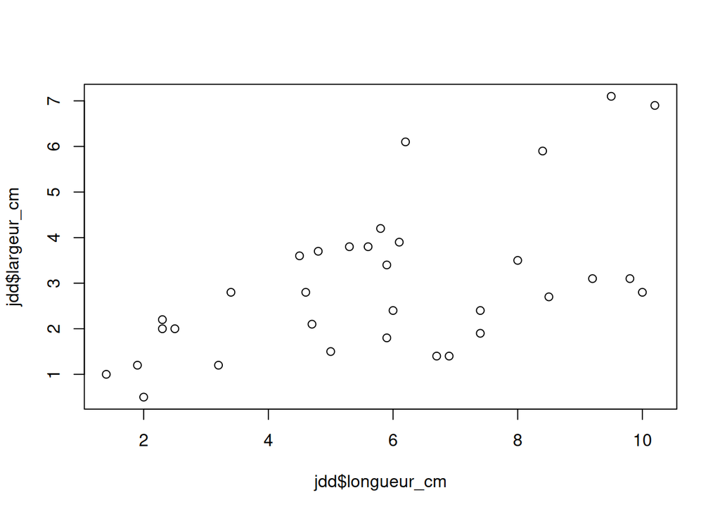

```r
plot(jdd$longueur_cm, jdd$largeur_cm)
```

Notez ici l’importance de bien séparer chaque argument par une `,` pour ne pas créer une erreur.

### B- Ajouter des titres

Si la fonction `plot()` nécessite ces deux arguments pour fonctionner, nous pouvons lui transmettre d’autres arguments annexes permettant notamment d’améliorer la qualité graphique. Par exemple, modifions un peu le titre des axes pour que ce soit plus clair.

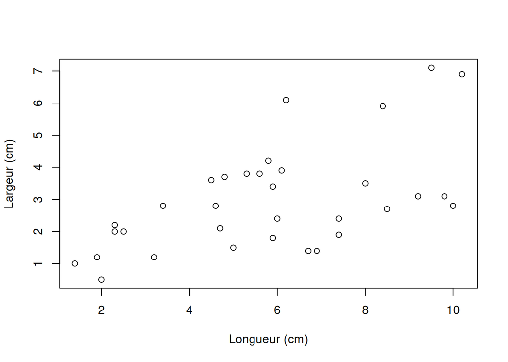

```r
plot(x = jdd$longueur_cm, y = jdd$largeur_cm,
     xlab = "Longueur (cm)", ylab = "Largeur (cm)") # afin d'éclaircir le code, il est possible de sauter une ligne avant de fermer la parenthèse !
```

Précisons ici que les textes entre guillemets `""` seront automatiquement considérés comme des objets de type character. Il est d’ailleurs possible de les définir avant de les inclure dans la fonction :

```r
xlabel <- "Longueur (cm)"
ylabel <- "Largeur (cm)"
```

et de les afficher :

```r
xlabel
```

```
## [1] "Longueur (cm)"
```

```r
ylabel
```

```
## [1] "Largeur (cm)"
```

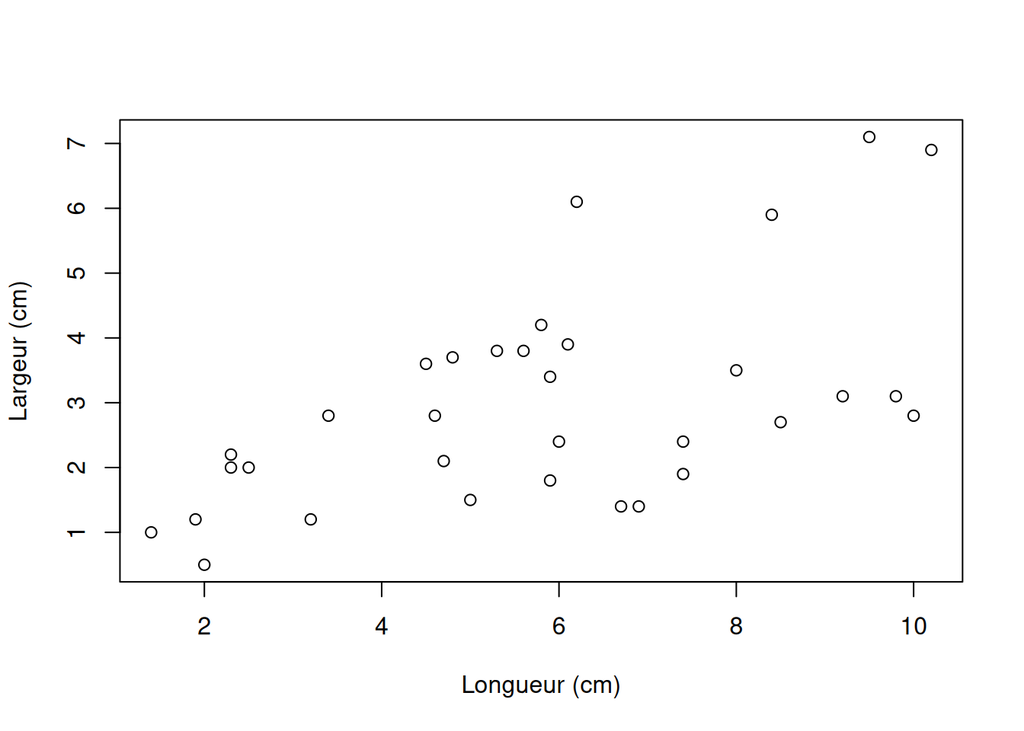

```r
plot(x = jdd$longueur_cm, y = jdd$largeur_cm, xlab = xlabel, ylab = ylabel)
```

Ajoutons également un titre !

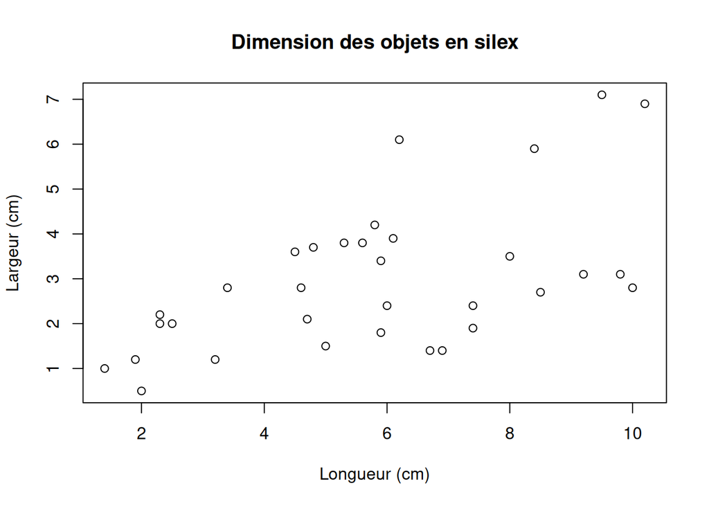

```r
title <- "Dimension des objets en silex"

plot(x = jdd$longueur_cm, y = jdd$largeur_cm,
     xlab = xlabel, ylab = ylabel,
     main = title)
```

### C- Modifier l’aspect des points (couleur, forme, taille)

Pour aller plus loin dans l’analyse, il est possible de colorer les points en fonction d’une catégorie. Voyons par exemple ce que cela donne avec la catégorie “type_fac”.

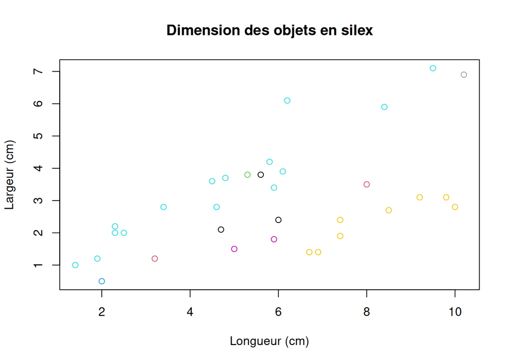

```r
plot(x = jdd$longueur_cm, y = jdd$largeur_cm,
     col = jdd$type_fac,
     xlab = xlabel, ylab = ylabel, main = title)
```

Il est possible de choisir d’autres couleurs que celles-ci, que personnellement je trouve assez criardes. Il existe tout un univers de palettes dans R, et vous pouvez explorer cela sur internet. Il y a notamment de nombreuses librairies qui codent des palettes prédéfinies, comme `wesanderson`, ou `viridis` (ce sont mes préférées). Dans la suite de l’exercice, je vais présenter deux façons d’utiliser des couleurs personnalisées : la méthode “basique” dans R, et l’emploi d’une librairie déjà codé.

Pour avoir totalement la main sur vous couleurs, vous pouvez utiliser les codes héxadécimaux :

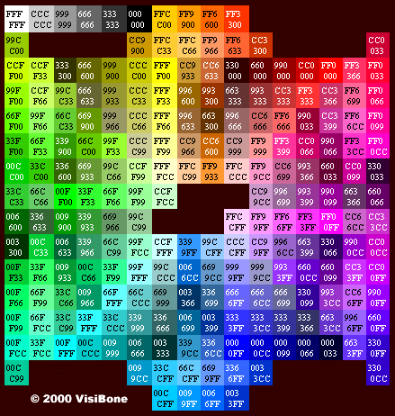

(Source: http://www.visibone.com)

Ou bien les couleurs directement codées dans R…

```r
head(colors()) # on emploie ici head() pour ne pas encombrer la console car il y a 657 couleurs en tout...
```

```
## [1] "white"         "aliceblue"     "antiquewhite"  "antiquewhite1"
## [5] "antiquewhite2" "antiquewhite3"
```

… dont vous pouvez voir les couleurs en suivant [ce lien](https://www.datanovia.com/en/fr/blog/liste-geniale-de-657-noms-de-couleur-dans-r/).

Tout d’abord, avec la fonction `length()`, je vérifie le nombre de valeurs dans la variable “type”. Cela me permet de savoir combien de couleurs sont nécessaires dans ma palette.

```r
length(levels(jdd$type_fac))
```

```
## [1] 10
```

Ensuite, avec la fonction `c()`, je créé deux listes de couleurs : l’une avec des code héxadécimaux, qui débutent toujours avec un `#` et l’une avec les couleurs pré-codées dans R. Retenez bien cette fonction, `c()`, qui est essentielle dans R. Elle permet de créer des listes d’objets et de les combiner.

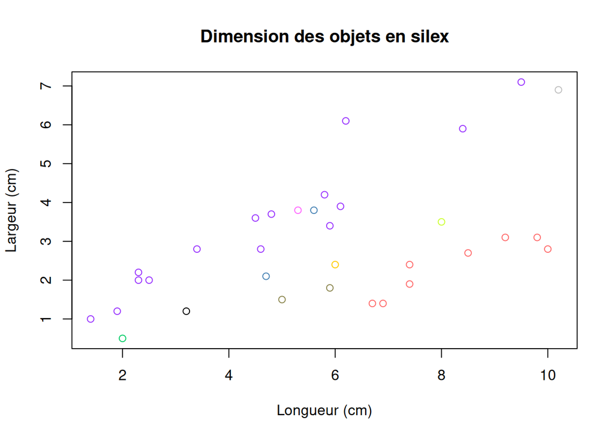

```r
pal1 <- c("#FFCC00", "#CCFF33", "#FF66FF", "#00CC66", "#9933FF") # première liste avec les codes héxadécimaux

pal2 <- c("khaki4", "indianred1", "grey", "steelblue", "black") # deuxième liste avec des couleurs précodées

pal <- c(pal1, pal2) # Combinaison des deux listes

plot(x = jdd$longueur_cm, y = jdd$largeur_cm,
     col = pal[as.numeric(jdd$type_fac)], # petite subtilité ici : on indique à la fonction que les couleurs correspondent à des niveaux de "type_fac" en convertissant ces derniers en valeurs numériques avec as.numeric().
     xlab = xlabel, ylab = ylabel, main = title)
```

Vous pouvez également installer des palettes de couleurs codées au sein de libraries. [Cette page](https://www.datanovia.com/en/blog/top-r-color-palettes-to-know-for-great-data-visualization/) recense de nombreuses palettes très jolies par exemple.

Petite démo avec ma palette préférée personnellement : `viridis` !

On installe d’abord la librairie :

```r
install.packages("viridis")
```

```r
library(viridis)
```

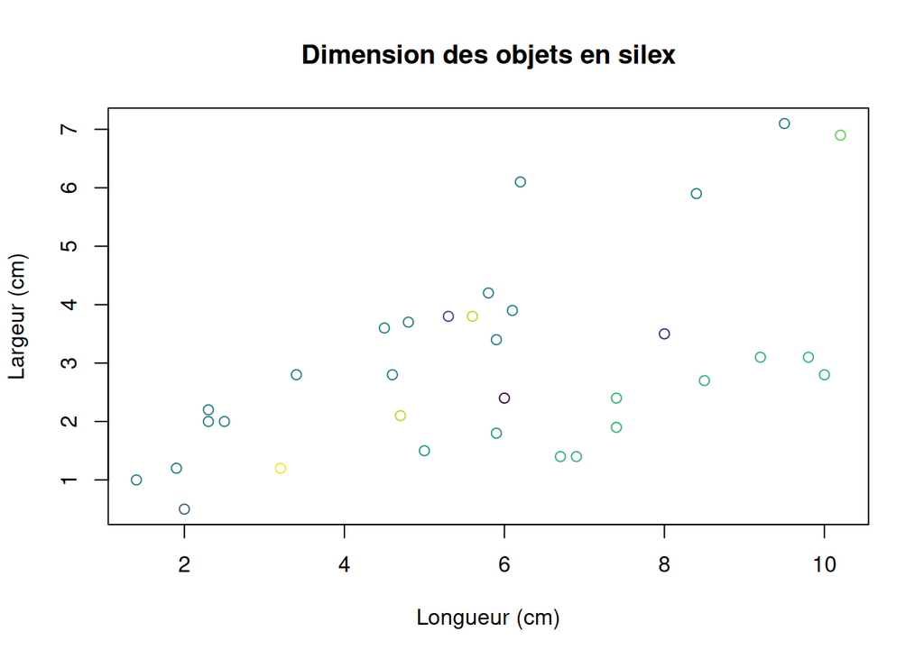

```r
plot(x = jdd$longueur_cm, y = jdd$largeur_cm,
     col = viridis(10)[as.numeric(jdd$type_fac)], # on indique à viridis() le nombre de couleurs nécessaires
     xlab = xlabel, ylab = ylabel, main = title)
```

On peut également changer la forme des points avec l’argument **“pch”**. Essayons de faire un graphique avec des formes différentes en fonction du type de silex.

**NB:** N’oublions pas de convertir notre colonne silex en facteur !

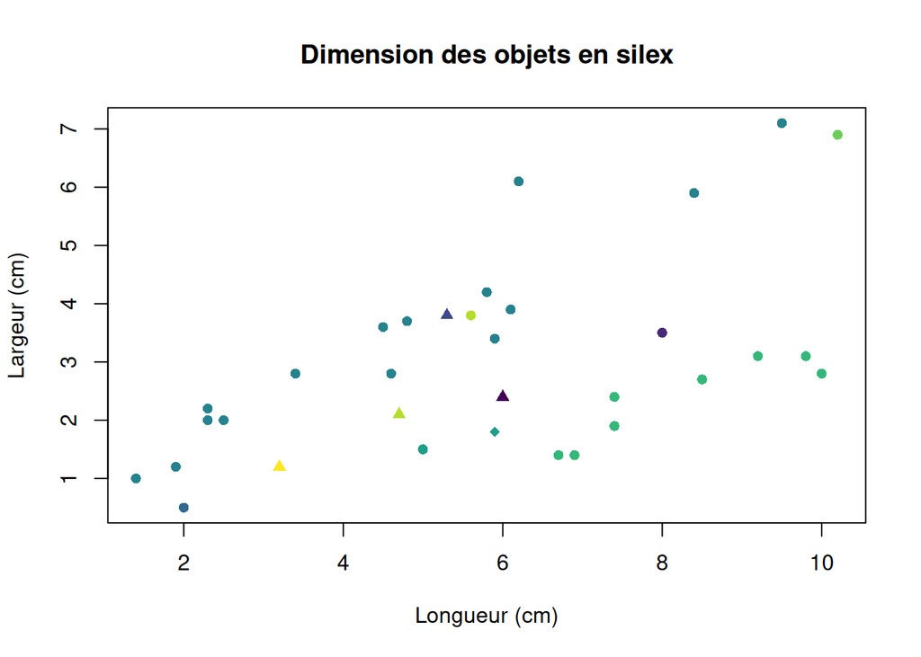

```r
jdd$silex_fac <- as.factor(jdd$silex)

plot(x = jdd$longueur_cm, y = jdd$largeur_cm,
     col = viridis(10)[as.numeric(jdd$type_fac)],
     pch = c(16, 17, 18)[as.numeric(jdd$silex_fac)],
     xlab = xlabel, ylab = ylabel, main = title)
```

Personnellement, je trouve que les points de ce graphe sont beaucoup trop petits pour être bien visibles. Heureusement, R nous permet de modifier leur taille au sein de la fonction `plot()`, avec l’argument **“cex”**.

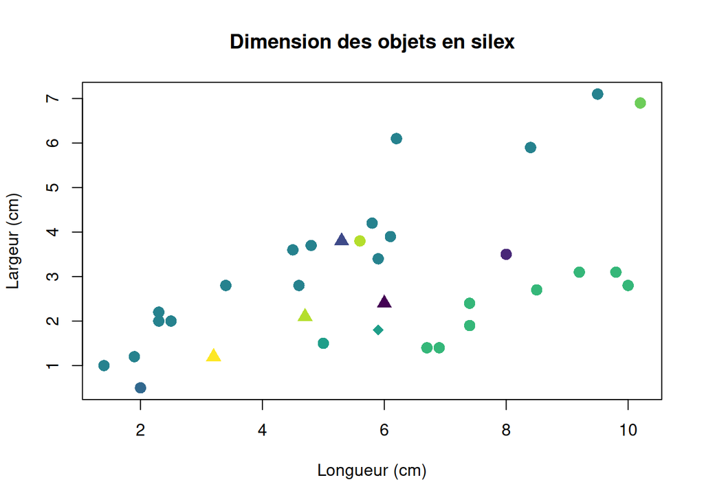

```r
plot(x = jdd$longueur_cm, y = jdd$largeur_cm,
     col = viridis(10)[as.numeric(jdd$type_fac)],
     pch = c(16, 17, 18)[as.numeric(jdd$silex_fac)],
     cex = 1.5,
     xlab = xlabel, ylab = ylabel, main = title)
```

### D- Ajouter des légendes

Afin de rendre encore plus lisible votre figure, vous pouvez également ajouter une légende avec la fonction `legend()`. Commençons par la légende des types de silex.

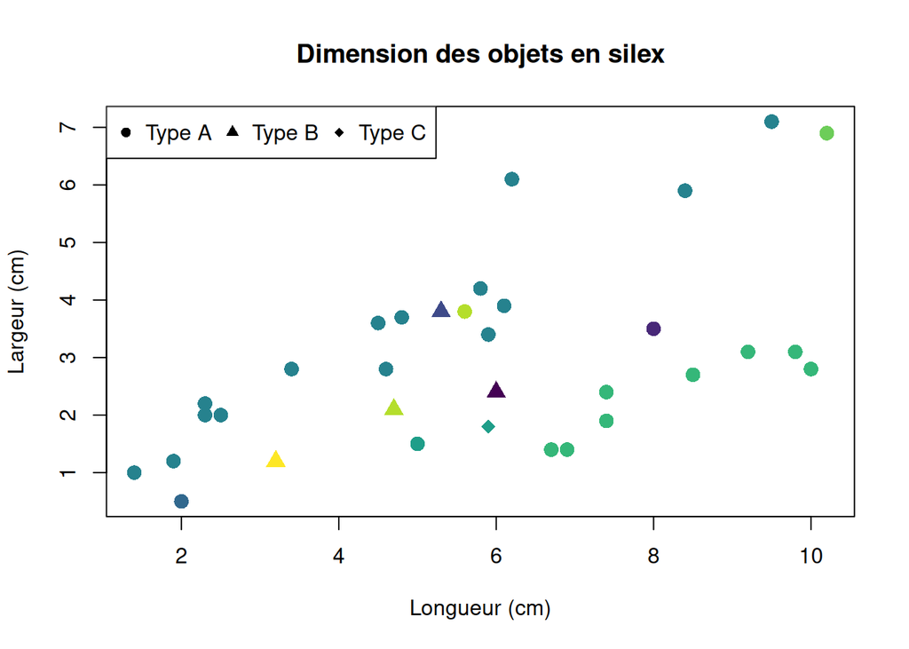

```r
plot(x = jdd$longueur_cm, y = jdd$largeur_cm,
     col = viridis(10)[as.numeric(jdd$type_fac)],
     pch = c(16, 17, 18)[as.numeric(jdd$silex_fac)],
     cex = 1.5,
     xlab = xlabel, ylab = ylabel, main = title)

legend("topleft", # ici préciser la position de la légende
       legend = c("Type A", "Type B", "Type C"), # ici préciser les légendes
       pch = 16:18, # ici préciser les shapes
       cex = 1, # on peut ici ajuster la taille de la légende
       horiz = TRUE) # ici, on précise si l'on souhaite que la légende soit horizontale ou verticale
```

Il est possible d’ajouter plusieurs légendes sur une même figure ! Il suffit de la mettre en suivant.

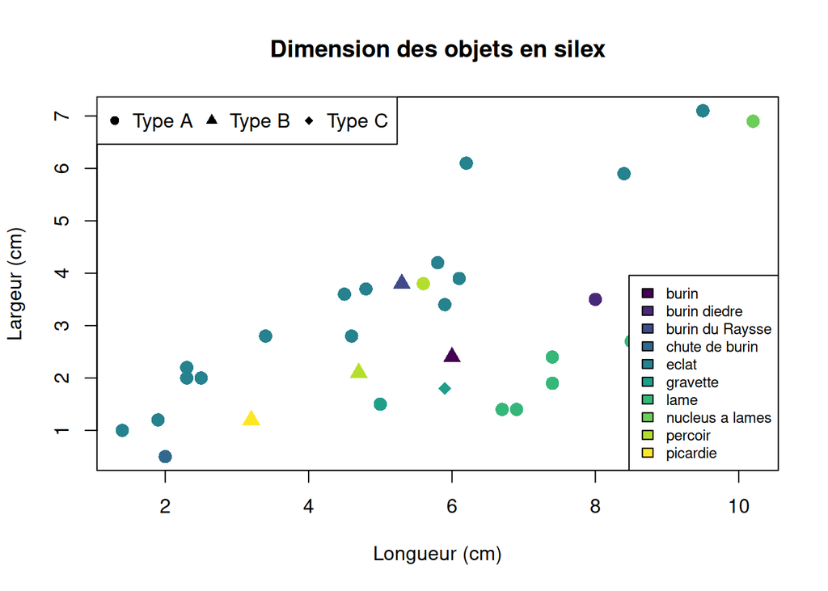

```r
plot(x = jdd$longueur_cm, y = jdd$largeur_cm,
     col = viridis(10)[as.numeric(jdd$type_fac)],
     pch = c(16, 17, 18)[as.numeric(jdd$silex_fac)],
     cex = 1.5,
     xlab = xlabel, ylab = ylabel, main = title)

legend("topleft",
       legend = c("Type A", "Type B", "Type C"),
       pch = 16:18,
       cex = 1,
       horiz = TRUE)

# Rajoutons la légende pour les types de pièces
legend("bottomright",
       legend = levels(jdd$type_fac),
       fill = viridis(10), # l'argument "fill" permet de préciser les couleurs sous la forme de rectangles de légende
       cex = 0.75)
```